# Statistical Inference Course Project

Edilmo Palencia

August 22, 2015

# Tooth Growth Analysis

The data present the next structure:

```
## 'data.frame':    60 obs. of  3 variables:
##  $ len : num  4.2 11.5 7.3 5.8 6.4 10 11.2 11.2 5.2 7 ...
##  $ supp: Factor w/ 2 levels "OJ","VC": 2 2 2 2 2 2 2 2 2 2 ...
##  $ dose: num  0.5 0.5 0.5 0.5 0.5 0.5 0.5 0.5 0.5 0.5 ...
```

We have 60 observations with tree variables: length is numeric, supplement is a factor and dose is numeric as well.

A quick summary of the data:

|  | len | supp | dose |
| --- | --- | --- | --- |
|  | Min. : 4.20 | OJ:30 | Min. :0.500 |
|  | 1st Qu.:13.07 | VC:30 | 1st Qu.:0.500 |
|  | Median :19.25 | NA | Median :1.000 |
|  | Mean :18.81 | NA | Mean :1.167 |
|  | 3rd Qu.:25.27 | NA | 3rd Qu.:2.000 |
|  | Max. :33.90 | NA | Max. :2.000 |

Let’s see how many observations we have per sup and types of doses:

```
##      dose 0.5  1  2
## supp
## OJ         10 10 10
## VC         10 10 10
```

Let’s see the distributions of the length per sup and dose:

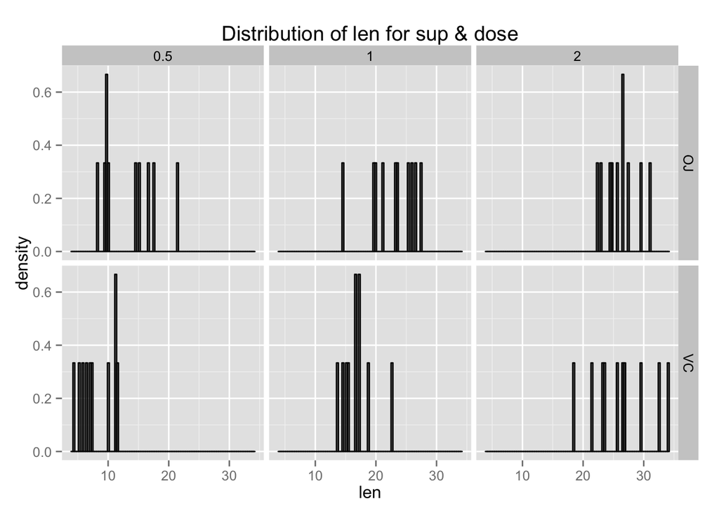

Let’s compute the t-test over len for each group of sup and dose:

```
##          OJ.0.5       VC.0.5       OJ.1         VC.1        OJ.2
## conf.int 10.03972     6.015176     19.90227     14.97066    24.16069
## conf.int 16.42028     9.944824     25.49773     18.56934    27.95931
## estimate 13.23        7.98         22.7         16.77       26.06
## p.value  6.074068e-06 7.209903e-06 1.933448e-08 5.69872e-09 1.833351e-10
##          VC.2
## conf.int 22.70791
## conf.int 29.57209
## estimate 26.14
## p.value  3.367967e-08
```

In the above table we can se for each group of sup and dose: the sample mean, the t confidence interval those means, and the p values.

## Asumptions

From the data presented above we precibe that the sup of value OJ is more efective than VC. To support this hipotesis let’s compare the means.

```
##
##  Paired t-test
##
## data:  OJ.means and VC.means
## t = 1.9472, df = 2, p-value = 0.1909
## alternative hypothesis: true difference in means is not equal to 0
## 95 percent confidence interval:
##  -4.475757 11.875757
## sample estimates:
## mean of the differences
##                     3.7
```

In the results presented we can see that the 95% confidence interval includes 0, with a p-value of .19 that is greater than .05

## Conclusions

There are few samples to confirm the assumption stated above. This conclussion is derived from the fact that the confidence interval includes the 0 and it is quite wide.